# ClassifyR 3 Figures and Results

## Metafeature Generation

Cell type proportions ignoring the spatial location of cells.

```r
library(spicyR)
proportions <- getProp(IMC, "description", "ImageNumber")
rownames(proportions) <- names(patientIDToImgID)[match(rownames(proportions), patientIDToImgID)]
proportions[1:5, 1:5]
```

```
##         B cells Basal CKlow Endothelial Fibroblasts Fibroblasts CD68+
## MB-0487       0 0.009307135 0.000000000  0.11478800       0.055842813
## MB-0623       0 0.000000000 0.035000000  0.33500000       0.010000000
## MB-0605       0 0.012820513 0.000000000  0.17307692       0.032051282
## MB-0661       0 0.000643915 0.006439150  0.02382486       0.007083065
## MB-0231       0 0.013100437 0.002183406  0.22707424       0.028384279
```

Calculate statistics for colocalisation between all pairs of cell types.

```r
library(BiocParallel)
pairsColocated <- getPairwise(IMC, sigma = 50, BPPARAM = MulticoreParam(16),
                              imageID = "ImageNumber", cellType = "description",
                              spatialCoordCols = c("Location_Center_X", "Location_Center_Y"))
rownames(pairsColocated) <- names(patientIDToImgID)[match(rownames(pairsColocated), patientIDToImgID)]
pairsColocated[1:5, 1:5]
```

```
##         B cells__B cells Basal CKlow__B cells Endothelial__B cells Fibroblasts__B cells Fibroblasts CD68+__B cells
## MB-0002       -170.00000          -170.000000           -170.00000          -170.000000                -170.000000
## MB-0010       -170.00000          -170.000000           -170.00000          -170.000000                -170.000000
## MB-0035       -170.00000          -170.000000           -170.00000          -170.000000                -170.000000
## MB-0060         45.84077            -4.924057             16.22443             2.554035                   0.159006
## MB-0064       -170.00000          -170.000000           -170.00000          -170.000000                -170.000000
```

Microenvironments by clustering.

```r
library(lisaClust)
IMC <- lisaClust(IMC, k = 10, sigma = 50, BPPARAM = MulticoreParam(16),
                 imageID = "ImageNumber", cellType = "description",
                 spatialCoords = c("Location_Center_X", "Location_Center_Y"))
```

```
## Generating local L-curves.
```

```r
regionsColocal <- getProp(IMC, feature = "region", "ImageNumber") # Extract newly-added information.
rownames(regionsColocal) <- names(patientIDToImgID)[match(rownames(regionsColocal), patientIDToImgID)]
regionsColocal[1:5, 1:5]
```

```
##            region_1  region_10   region_2   region_3 region_4
## MB-0487 0.010341262 0.06514995 0.05687694 0.47259566    0.000
## MB-0623 0.010000000 0.00000000 0.02500000 0.08000000    0.255
## MB-0605 0.000000000 0.05128205 0.07051282 0.50000000    0.000
## MB-0661 0.025756600 0.05795235 0.04700580 0.09207985    0.000
## MB-0231 0.002183406 0.30567686 0.28165939 0.01965066    0.000
```

Average highly-variable gene expression per cell type.

```r
library(scFeatures)
colData(IMC)$x_cord <- colData(IMC)$Location_Center_X
colData(IMC)$y_cord <- colData(IMC)$Location_Center_Y
HVGaverages <- scFeatures(assay(IMC, "counts"), feature_types = "gene_mean_celltype", type = "spatial_p",
                  sample = colData(IMC)$ImageNumber,
                  celltype = colData(IMC)$description,
                  ncores = 16)[["gene_mean_celltype"]]
```

```
## generating gene mean celltype features
```

```r
rownames(HVGaverages) <- names(patientIDToImgID)[match(rownames(HVGaverages), patientIDToImgID)]
HVGaverages[1:5, 1:5]
```

```
##         HR- CK7+--DNA2 HR- CK7+--DNA1 HR- CK7+--CK7 HR- CK7+--CK8_18 HR- CK7+--Fibronectin
## MB-0487       56.54894       31.17875     15.313471        10.954694             6.5608141
## MB-0623        0.00000        0.00000      0.000000         0.000000             0.0000000
## MB-0605       99.25316       54.08847      7.083691        17.506416            23.0795169
## MB-0661       42.09568       23.71769      5.322767        11.870986             1.5151112
## MB-0231      119.03189       65.64093      8.130328         4.431196             0.5716568
```

Proportions relative to a parent cell type.

```r
library(treekoR)

tree <- getClusterTree(t(assay(IMC, "counts")), colData(IMC)$description,
                       hierarchy_method = "hopach")

proportionsParent <- getCellProp(tree$clust_tree, colData(IMC)$description, colData(IMC)$metabricId,
                                 colData(IMC)$metabricId)
rownames(proportionsParent) <- proportionsParent$sample_id
proportionsParent[is.na(proportionsParent)] <- 0
proportionsParent <- proportionsParent[rownames(proportions), -c(1:2)]
proportionsParent <- proportionsParent[, grep("parent", colnames(proportionsParent))]
proportionsParent[1:5, 1:5]
```

```
##         perc_parent_1_HR- CK7+ perc_parent_1_HER2+ perc_parent_1_HR+ CK7- perc_parent_1_HR+ CK7- Slug+ perc_parent_1_Basal CKlow
## MB-0487            0.880758808         0.000000000              1.0000000                  0.000000000                0.81818182
## MB-0623            0.000000000         0.000000000              1.0000000                  0.000000000                0.00000000
## MB-0605            0.086419753         0.012345679              0.7945205                  0.205479452                0.50000000
## MB-0661            0.004389816         0.004389816              0.9920283                  0.007971656                0.02857143
## MB-0231            0.866666667         0.006060606              1.0000000                  0.000000000                1.00000000
```

## Survival Time Modelling and C-index Evaluation

Create a list of all data tables.

```r
measurements <- list(clinical = clinical, `RNA Microarray` = RNAarrays, `Type Proportions` = proportions,
                     `Type Protein Mean` = HVGaverages, `Type Pairs Colocated` = pairsColocated,
                     `Colocated in Regions` = regionsColocal, `Proportion of Parent` = proportionsParent)
sapply(measurements, dim)
```

```
##      clinical RNA Microarray Type Proportions Type Protein Mean Type Pairs Colocated Colocated in Regions Proportion of Parent
## [1,]      165            165              165               165                  165                  165                  165
## [2,]       30           2000               22               858                  484                   10                   55
```

Cox survival model for each assay individually.

```r
orderAssays <- c("clinical", "Type Proportions", "RNA Microarray",
                 "Proportion of Parent", "Colocated in Regions", "Type Protein Mean", "Type Pairs Colocated")
nFeatures = list(clinical = 1:3, `RNA Microarray` = c(5, 10, 20, 50), `Type Proportions` = 1:5,
                 `Proportion of Parent` = 1:5, `Colocated in Regions` = 1:5,
                 `Type Protein Mean` = 1:5, `Type Pairs Colocated` = 1:5)

coxPredicts <- crossValidate(measurements, c("timeRFS", "eventRFS"),
                             extraParams = list(prepare = list(useFeatures = list(clinical = usefulFeatures)),
                                                select = list(tuneParams = list(nFeatures = nFeatures)),
                                                tuneCross = list(performanceType = "auto", tuneMode = "Resubstitution")),
                             selectionMethod = "CoxPH", classifier = "CoxPH", nCores = 20, verbose = 1)
```

```
## 2024-12-13 14:47:13.240118: Running selection CoxPH, classifier CoxPH.
```

```
## 2024-12-13 14:47:19.937115: Running selection CoxPH, classifier CoxPH.
```

```
## 2024-12-13 14:47:30.277404: Running selection CoxPH, classifier CoxPH.
```

```
## 2024-12-13 14:47:36.712832: Running selection CoxPH, classifier CoxPH.
```

```
## 2024-12-13 14:47:44.389702: Running selection CoxPH, classifier CoxPH.
```

```
## 2024-12-13 14:47:51.421949: Running selection CoxPH, classifier CoxPH.
```

```
## 2024-12-13 14:47:56.506713: Running selection CoxPH, classifier CoxPH.
```

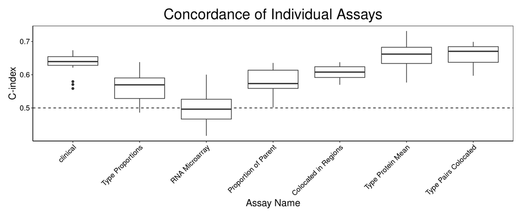

```r
performancePlot(coxPredicts, orderingList = list(`Assay Name` = orderAssays)) +
    theme(axis.text.x = element_text(angle = 45, vjust = 1, hjust = 1)) + ggtitle("Concordance of Individual Assays")
```

Evaluate the features being repeatedly chosen for the well-performing clinical data.

```r
table(unlist(do.call(rbind, chosenFeatureNames(coxPredicts[["clinical.CoxPH.CoxPH"]]))[, "feature"]))
```

```
##
## Breast.Tumour.Laterality                ER.Status                    Grade                     Size                    Stage
##                        9                       66                       97                       58                       68
```

Grade, tumour size and stage are all frequently chosen.

Cox survival model for concatenation of assays.

```r
coxMergePredicts <- crossValidate(measurements, c("timeRFS", "eventRFS"),
                                  extraParams = list(prepare = list(useFeatures = list(clinical = usefulFeatures)),
                                                select = list(tuneParams = list(nFeatures = nFeatures)),
                                                tuneCross = list(performanceType = "auto", tuneMode = "Resubstitution")),
                                  multiViewMethod = "merge",
                                  selectionMethod = "CoxPH", classifier = "CoxPH", nRepeats = 20, nCores = 20, verbose = 1)
```

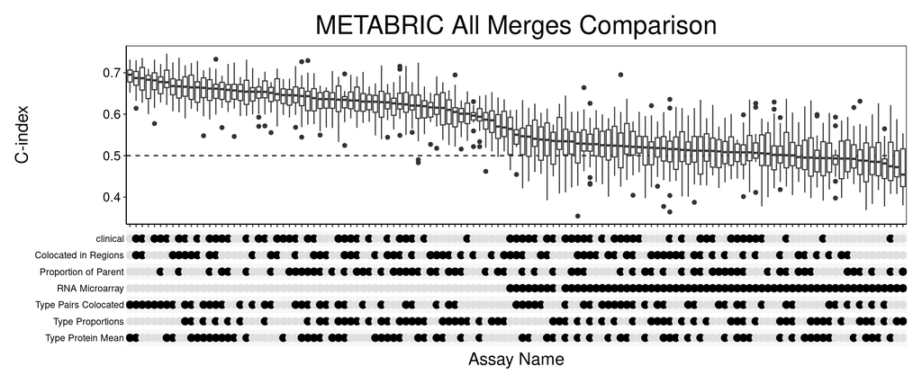

```r
performancePlot(coxMergePredicts, orderingList = list("Assay Name" = "performanceDescending")) +
  theme(axis.text.x = element_text(angle = 45, size = 6, vjust = 1, hjust = 1)) + ggtitle("METABRIC All Merges Comparison")
```

Clinical, Type Protein Mean features.

```r
mergeFeatureCounts <- table(unlist(do.call(rbind, chosenFeatureNames(coxMergePredicts[[10]]))[, "feature"]))
mergeFeatureCounts <- sort(mergeFeatureCounts, decreasing = TRUE)
head(mergeFeatureCounts, 10)
```

```
##
##              Grade    HR- Ki67+--Sox9              Stage               Size          ER.Status  HRlow CKlow--Ki67  Fibroblasts--Ki67
##                 99                 95                 67                 64                 62                 54                 50
## HRlow CKlow--GATA3  Fibroblasts--Sox9  HRlow CKlow--Sox9
##                 29                 27                 19
```

In addition to the clinical data, Ki67 is a repeatedly selected omics feature. According to Wikipedia, “Ki-67 is an excellent marker to determine the growth fraction of a given cell population. The fraction of Ki-67-positive tumor cells (the Ki-67 labeling index) is often correlated with the clinical course of cancer.”. So, it is an unsurprising and to-be-expected predictor variable.

Cox survival model for prevalidation (concatenate each assay as one column to the clinical data).

```r
coxPrevalPredicts <- crossValidate(measurements, c("timeRFS", "eventRFS"),
                     extraParams = list(prepare = list(useFeatures = list(clinical = usefulFeatures)),
                                                select = list(tuneParams = list(nFeatures = nFeatures)),
                                                tuneCross = list(performanceType = "auto", tuneMode = "Resubstitution")),
                     multiViewMethod = "prevalidation", nRepeats = 20, nCores = 20,
                     selectionMethod = "CoxPH", classifier = "CoxPH", verbose = 1)
```

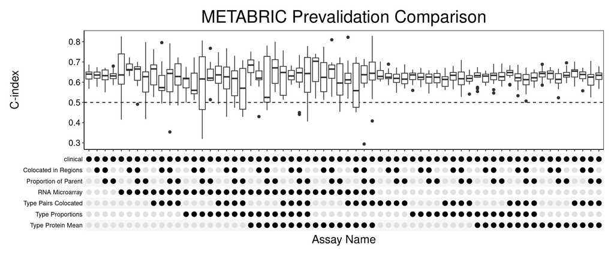

```r
performancePlot(coxPrevalPredicts) + ggtitle("METABRIC Prevalidation Comparison")
```

Cox survival model for Principal Components Analysis dimensionality reduction (concatenate each principal component as one column to the clinical data).

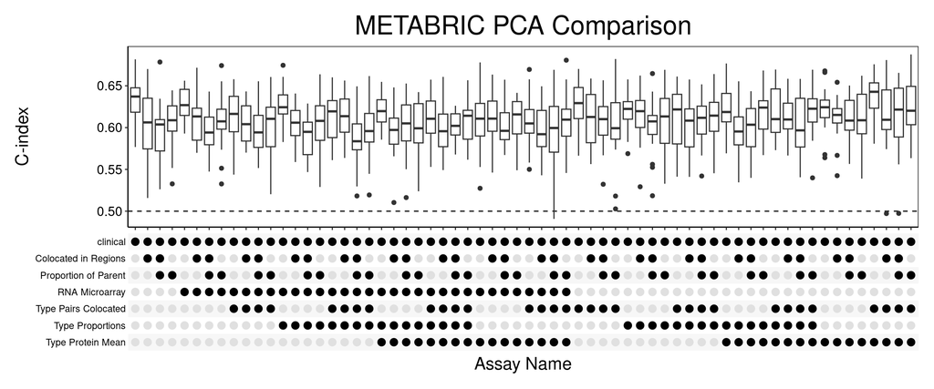

```r
nFeatures = list(clinical = 1:3, `RNA Microarray` = 2, `Type Proportions` = 2,
                 `Proportion of Parent` = 2, `Colocated in Regions` = 2,
                 `Type Protein Mean` = 2, `Type Pairs Colocated` = 2)
PCApredicts <- crossValidate(measurements, c("timeRFS", "eventRFS"),
               multiViewMethod = "PCA", nRepeats = 20, nCores = 20,
               extraParams = list(prepare = list(useFeatures = list(clinical = usefulFeatures)),
                                                select = list(tuneParams = list(nFeatures = nFeatures)),
                                                tuneCross = list(performanceType = "auto", tuneMode = "Resubstitution")),
               selectionMethod = "CoxPH", classifier = "CoxPH", verbose = 1)
performancePlot(PCApredicts) + ggtitle("METABRIC PCA Comparison")
```